# YouTube Watch History Analysis

## Exploring My Youtube Watch History

An exploration of my YouTube viewing habits — what I watch, how long I watch, and how I feel about the content.

## What kind of content do I watch most?

Across all my logged sessions, I found that some categories consistently have **longer average video lengths** than others.

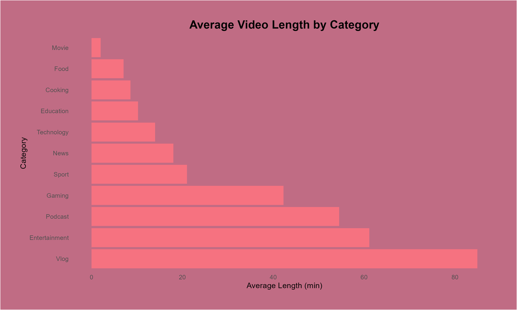

Bar plot of average video length by category

Vlog or Entertainment categories tend to be longer, while movie and food videos are often short and snappy.  
This gives a sense of which content I tend to “invest” more time into.

## Did I actually enjoy what I watched?

Not every video is a hit. I compared **enjoyment ratings** across whether I would recommend the video or not.

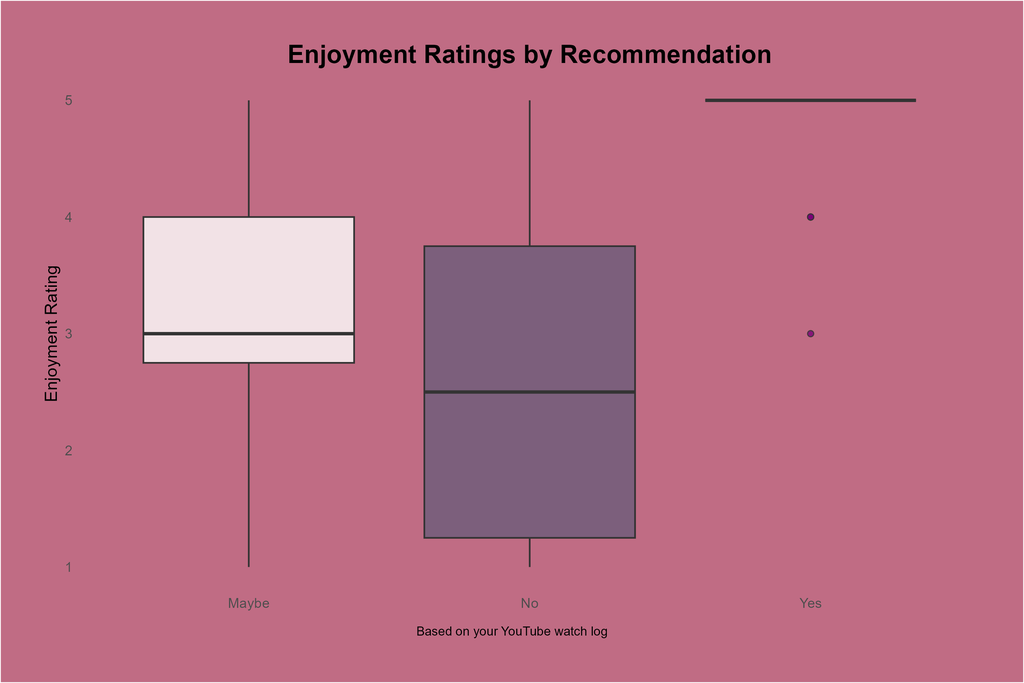

Boxplot showing enjoyment ratings grouped by recommendation

It is not suprising, the videos I would **recommend** had higher enjoyment ratings. Interestingly, even videos rated “maybe” still had decent enjoyment scores — showing some content sits in a grey zone of “okay but not quite recommendable.”

## How often and how long did I log my data?

Looking at the **time gaps between logs**, I visualised the minutes between each entry.

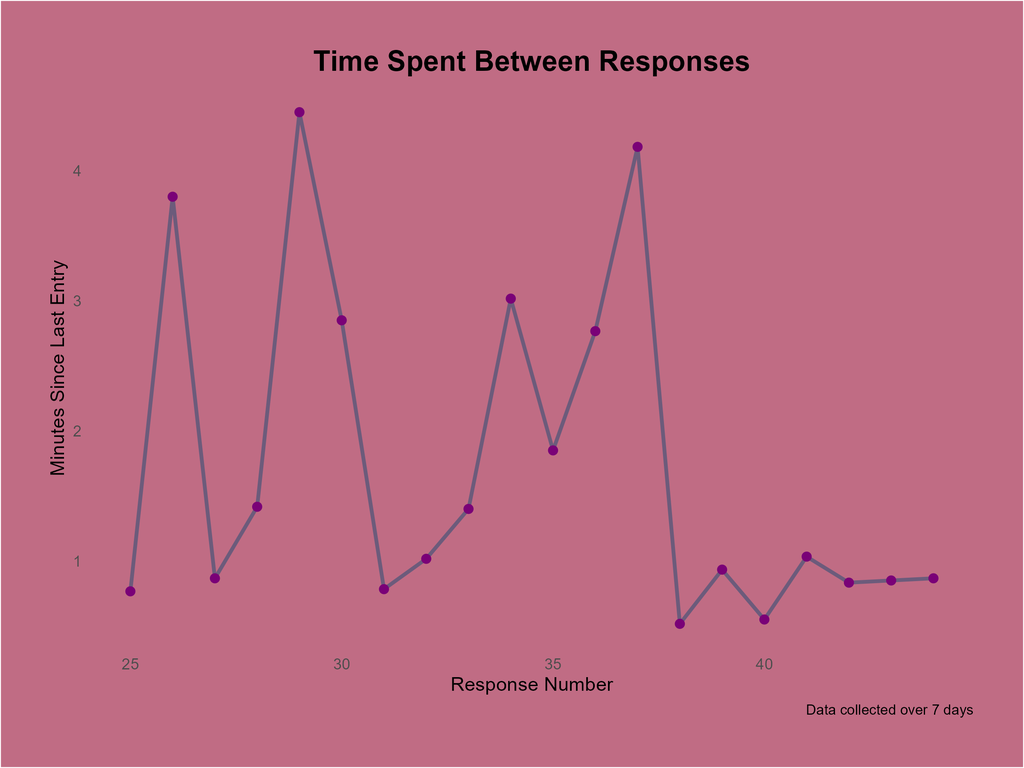

Line plot showing minutes between logged entries (last 20 only)

Some entries were logged **very close together**, while others had big gaps — maybe reflecting how I dedicated to give a comment about the video. This plot focuses on the **last 20 entries** to highlight recent behaviour.

## In Conclusion

I learned more about my YouTube habits — not just what I watch, but how often I engage, how long I’m willing to spend, and what I enjoy most.

It’s surprising how much you can reflect on **personal behaviour** just from a spreadsheet and a few plots!